# Análise de Dados de Transcriptômica Espacial

Aula 01 - Introdução às transcriptômicas de alta resolução

Lana Bazan Peters Querne

Doutoranda, PPGAB, UFPR

## Análise de Dados de Transcriptômica Espacial

Objetivos

- Apresentar os fundamentos teóricos relacionadas à transcriptômica de alta resolução, com foco em **transcriptômica espacial**.
- **Treinamento prático** com os passos fundamentais para a análise desse tipo de dado.
- **Capacitação para aplicação** desses fundamentos nas áreas da Ciência da Saúde e Biológicas.

## Conteúdo do curso

Planejamento das aulas:

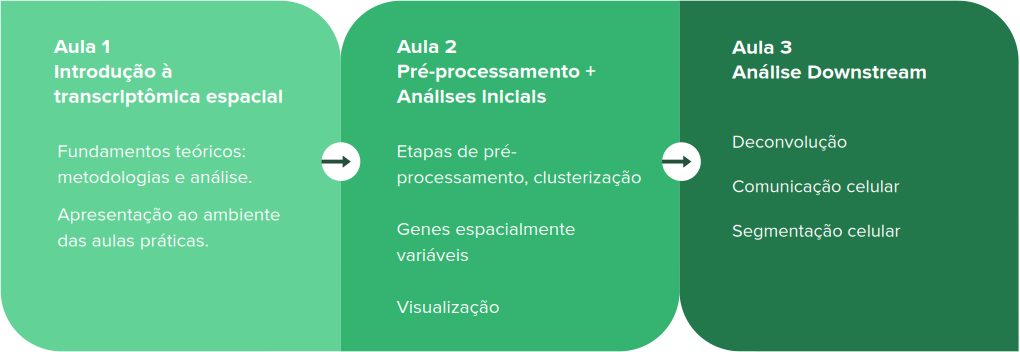

## Roteiro da aula

- Apresentações;
- Fundamentos teóricos;
  - Objetivo de transcriptômicas de alta resolução;
  - Métodos de transcriptômica de células individuais;
  - Métodos de transcriptômica espacial;
  - Análise de dados;
  - Workflows de análise de dados de transcriptômica espacial.
- Preparação do ambiente para análise.

# Apresentação

## Instrutores

Flávio Gabriel Carazza Kessler

- Doutorando em Bioinformática na UFPR
- flaviogckessler@gmail.com

Jonathan André Back

- Mestrando em Bioinformática na UFPR

Lana Bazan Peters Querne

- Doutoranda em Bioinformática na UFPR
- lanapeters@ufpr.br

Github do laboratório: github.com/sysbiolab

## Participantes

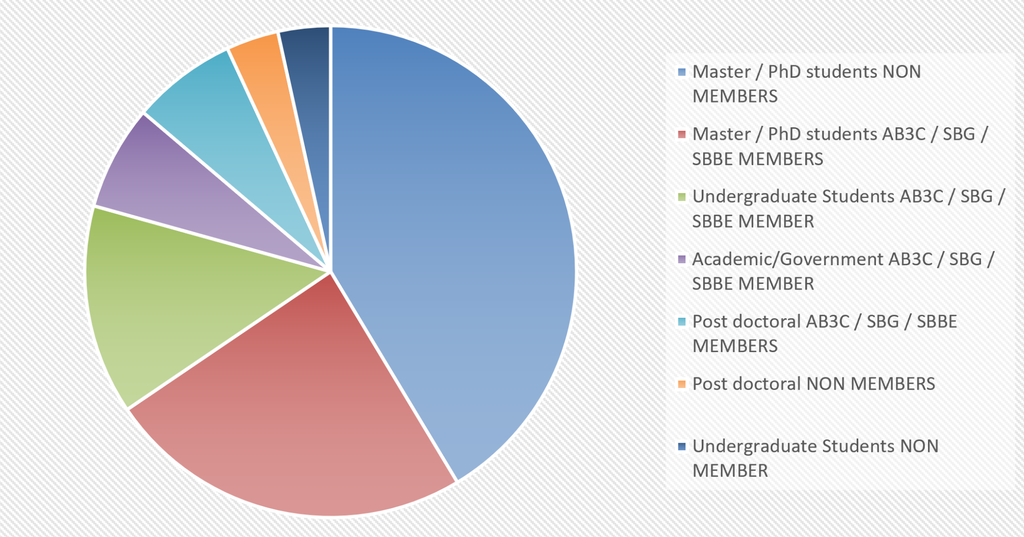

Perfil dos participantes (Curso semelhante anterior).

[figure not shown]

QR Code para questionário de apresentação

## Ambiente do curso

- Atividades práticas: **Google Classroom**
- [Tutorial do RStudio para iniciantes: Um guia completo | DataCamp](https://www.datacamp.com/pt/tutorial/r-studio-tutorial)

# Fundamentos teóricos

## Objetivo de transcriptômicas de alta resolução

### Amostras biológicas têm diferentes níveis de complexidade

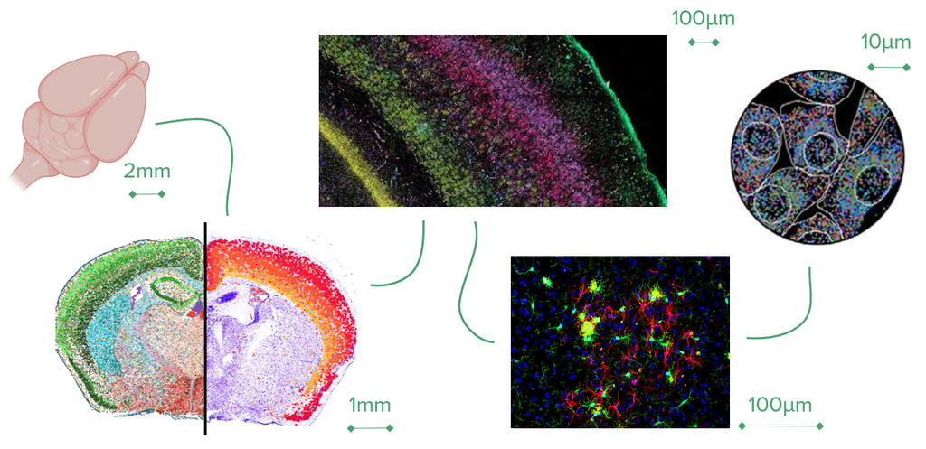

### Lisados celulares mascaram essa complexidade

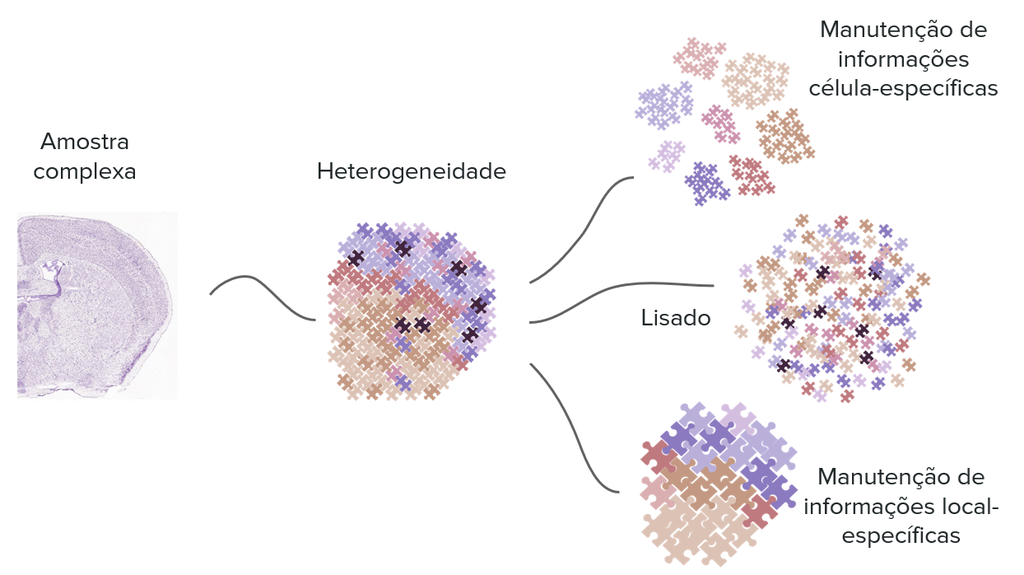

### Essa complexidade tem relevância clínica

[figure not shown]

## Transcriptômica com Sequenciamento de Nova Geração (NGS)

1. **Preparo de biblioteca**: Síntese de cDNA, fragmentação, adição de adaptadores;
2. **Sequenciamento**: Amplificação e sequenciamento em si;
3. **Análise**: Controle de qualidade, alinhamento, quantificação, normalização e expressão diferencial.
- Sendo que, na transcriptômica de alta resolução, a etapa de `preparo de biblioteca` mantém a informação célula-específica ou espaço-específica, e as `análises` são de um conjunto de dados de alta heterogeneidade e dimensionalidade.

# Métodos de transcriptômica de células individuais

## Single-cell RNA-seq (scRNA-seq)

### Evolução de tecnologias

[figure not shown]

## Single-cell RNA-seq (scRNA-seq)

### Evolução de tecnologias

[figure not shown]

## Single-cell RNA-seq (scRNA-seq)

### Evolução de tecnologias

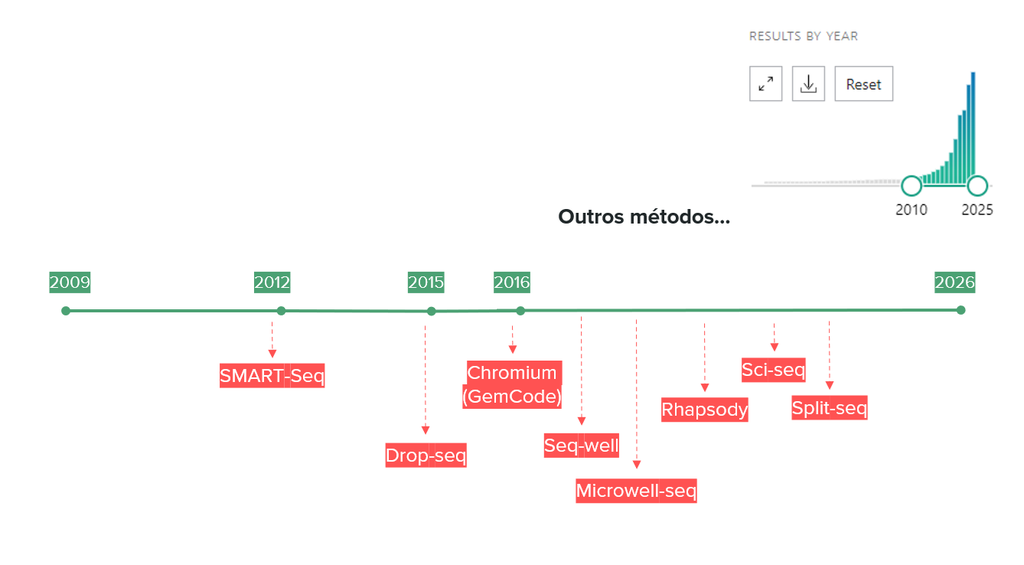

## Single-cell RNA-seq (scRNA-seq)

### Princípios

As técnicas de transcriptômica de células individuais envolvem alguns desafios:

1. Obtenção de células únicas;
2. Amplificação de cDNA de forma célula-específica;
3. Marcação das bibliotecas de cDNA de forma célula-específica

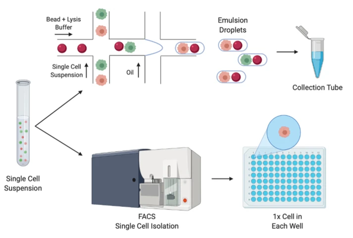

## Single-cell RNA-seq (scRNA-seq)

### Princípios

#### Chromium 10X Genomics (droplet-seq)

[figure not shown]

[figure not shown]

## Single-cell RNA-seq (scRNA-seq)

### Princípios

#### Chromium 10X Genomics (droplet-seq)

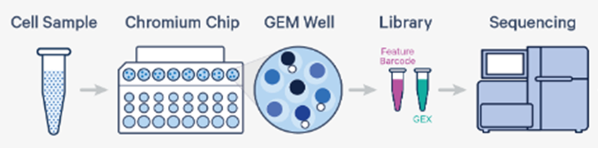

- **Preparo de amostra**
  - **Suspensão de células únicas!**;
  - Preparo tecido-dependente;
  - Perda de células sensíveis.
- **Captura de células únicas**
  - Baseado em gotículas (**droplet-based**), formadas por **microfluídica**.
- **Biblioteca de cDNA**
  - **Transcrito incompleto** (extremidade 5’ ou 3’);
  - Amplificação por PCR.
- **Sequenciamento (NGS)**
  - **Baixa cobertura** (muitos transcritos ficam de fora!).

Poder suficiente para **separar tipos e estados celulares**.

Excelente **custo-benefício**: células/$.

Não é o melhor método para caracterizar profundamente o perfil transcricional de população celulares.

## Single-cell RNA-seq (scRNA-seq)

### Outros métodos

#### BD Rhapsody (nanowell-based)

Captura de células únicas - Baseado em nanopoços (**nanowell-based**)

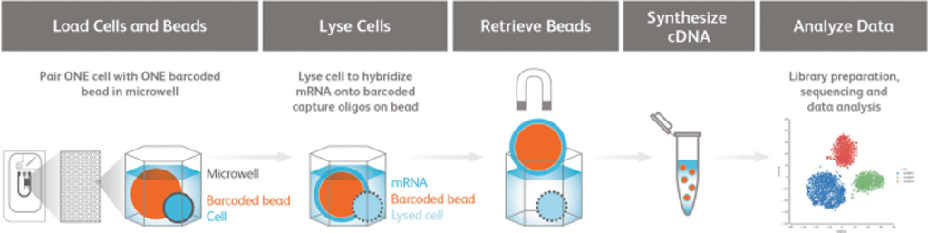

## Single-cell RNA-seq (scRNA-seq)

### Droplet-based vs. Plate-based

|  | Droplet-based | Plate-based |
| --- | --- | --- |
| **Detected genes/per cell** | 200-5000 | 4000 ~ 8000 |
| **Detected cells** | 1 k-10 k per run | 1 cell per well |
| **Processing time** | ~ 9-10 h | ~ 25 h |
| **Type of RNA analyzed** | 3’ - or 5’ end cDNA | Full length cDNA |

## Conteúdos extras

Princípios e planejamento experimental

- **Haque et al, 2017. DOI 10.1186/s13073-017-0467-4** A practical guide to single-cell RNA-sequencing for biomedical research and clinical applications

Métodos de geração de bibliotecas scRNA-seq

- **De Simone et al, 2025. DOI 10.1093/nar/gkae1186** A comprehensive analysis framework for evaluating commercial single-cell RNA sequencing technologies
- **Vídeo: Single Cell Gene Expression Protocol v3.1 | Assemble Chromium Next GEM Chip G** https://www.youtube.com/watch?v=cH8ldAqKUzE

# Métodos de transcriptômica

## RNA-seq espacial

### Evolução de tecnologias

[figure not shown]

## RNA-seq espacial

### Evolução de tecnologias

[figure not shown]

## RNA-seq espacial

### Evolução de tecnologias

[figure not shown]

## RNA-seq espacial

### Princípios

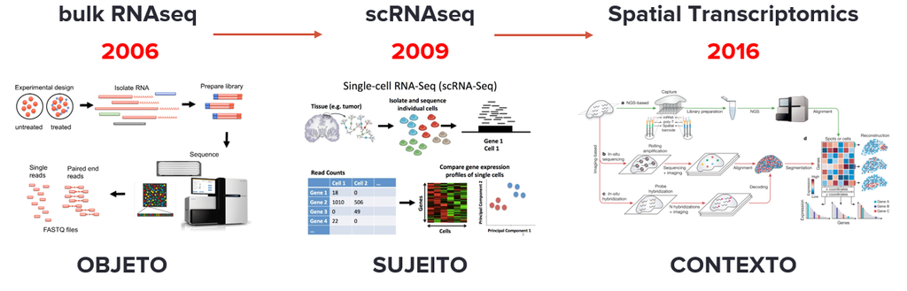

## RNA-seq espacial

### Princípios

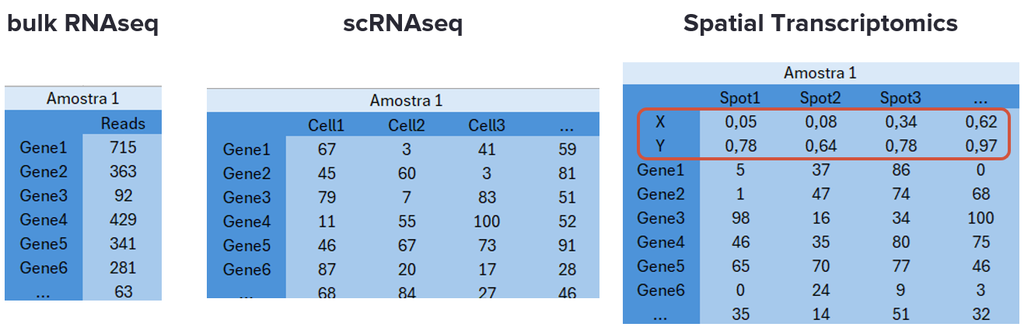

## RNA-seq espacial

### Tecnologias

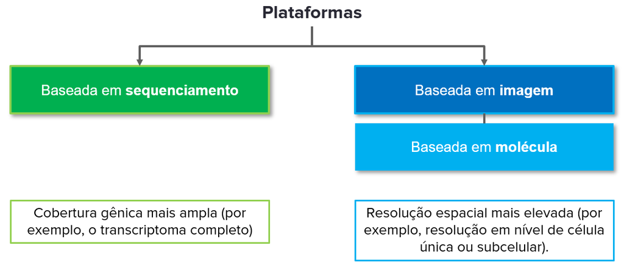

## RNA-seq espacial

### Tecnologias

#### Transcriptômica espacial baseada em sequencimento

- Capturam **informações moleculares** em um conjunto de locais de medição espacial em um corte de tecido disposto sobre uma lâmina;
  - A **localização espacial** é identificada por meio de um **código de barras** (barcode) exclusivo para cada ponto de medição, e as leituras são sumarizadas (por exemplo, na forma de contagens) de acordo com características como genes ou segmentos (bins).
- **Vantagem**: as características representam um conjunto não direcionado (untargeted) de entidades moleculares, dispensando, portanto, a seleção e a otimização de painéis;
  - Na prática, muitos ensaios espaciais ainda exigem painéis (ex.: variantes espaciais de CITE-seq, Visium v2 e Visium HD).
- A **resolução espacial** varia entre as plataformas e depende do tamanho e do espaçamento entre os locais de medição espacial.
  - Os locais de medição espacial são frequentemente denominados “spots”, “beads” ou “bins”.

## RNA-seq espacial

### Tecnologias

#### Transcriptômica espacial baseada em sequencimento

[figure not shown]

## RNA-seq espacial

### Tecnologias

#### Transcriptômica espacial baseada em imagem

- Identificam a localização espacial de moléculas de RNA individuais por meio de **hibridização in situ sequencial (ISH)** ou **sequenciamento in situ (ISS)**, abrangendo painéis direcionados de até centenas ou milhares de genes;
  - Transcritos são identificados individualmente → dados brutos são coletados com **resolução espacial subcelular**.
- A **segmentação de imagens** é utilizada para **identificar os limites de células ou núcleos individuais** e, durante o pré-processamento, associar as moléculas de RNA a essas células ou núcleos;
- A **seleção de conjuntos direcionados de genes** biologicamente informativos para um experimento — processo conhecido como **desenho de painel** (panel design) — é um aspecto fundamental no planejamento experimental.

## RNA-seq espacial

### Tecnologias

#### Transcriptômica espacial baseada em imagem

[figure not shown]

## RNA-seq espacial

### Tecnologias - Princípios

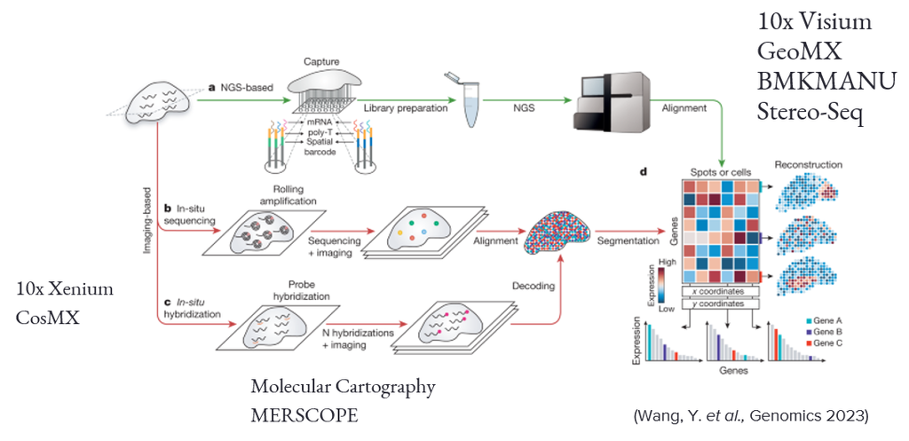

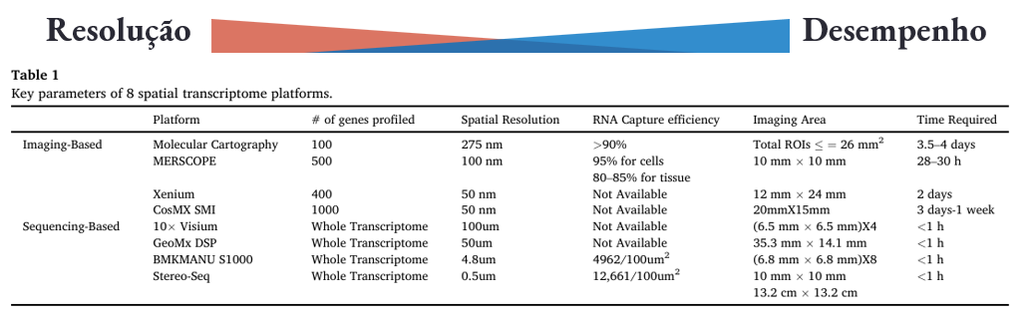

## RNA-seq espacial

### Princípios - Tecnologia Visium

[figure not shown]

## RNA-seq espacial

### Princípios - Tecnologia Visium

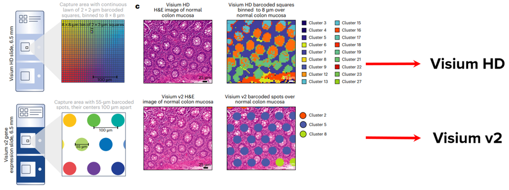

[Visium HD paper](http://doi.org/10.1038/s41588-025-02193-3): Oliveira et al. (2025)

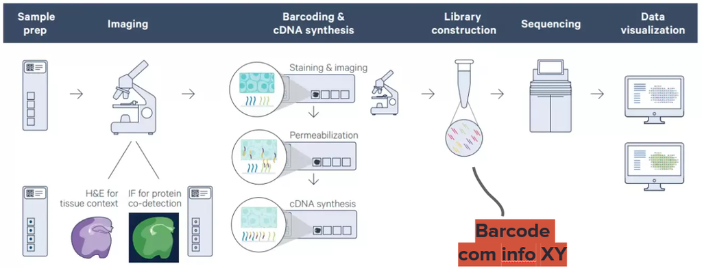

## RNA-seq espacial

### Princípios - Tecnologia Visium

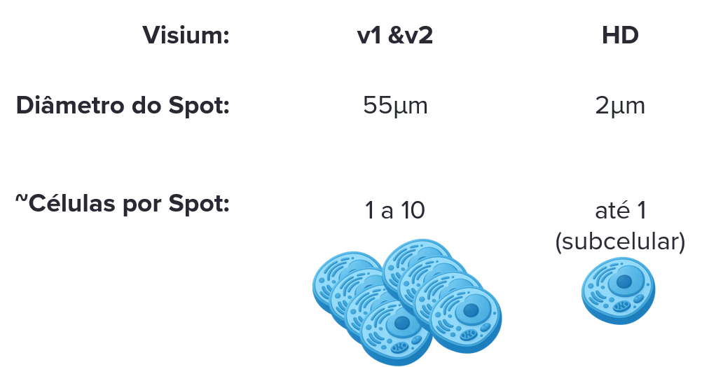

## Conteúdos extras

Métodos de geração de bibliotecas de RNA-seq espacial

- **Moffitt et al, 2022. DOI 10.1038/s41576-022-00515-3** The emerging landscape of spatial profiling technologies.
- **Vídeo: Série Visium Spatial Gene Expression Protocol** https://www.youtube.com/playlist?list=PLfaSRwcfHcq1acX1nuTFcUGClpNRPEyHH

# Análise de dados

## Passos da análise de dados de transcriptômica de alta resolução

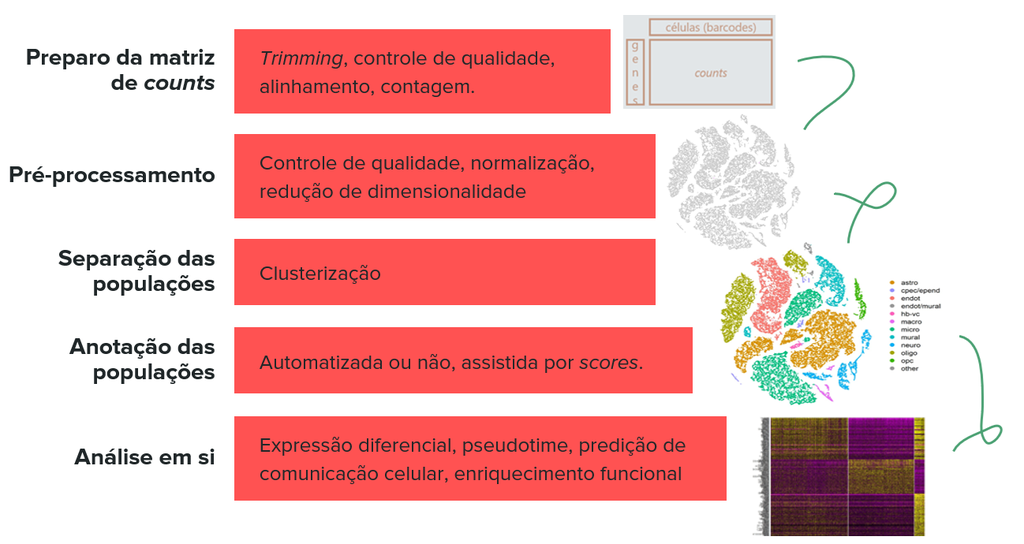

## Passos da análise de dados de transcriptômica de alta resolução

### Preparo da matriz de counts

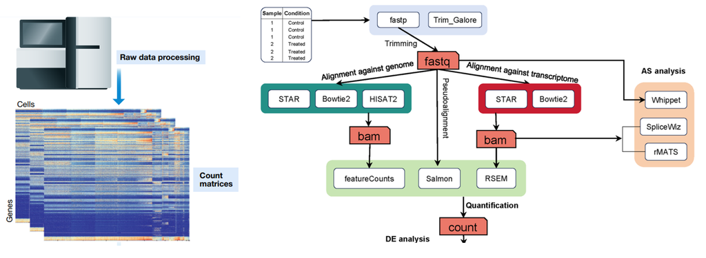

No caso de tecnologias da 10x Genomics (Visium): Essas etapas são realizadas ferramentas internas: - Cell Ranger - [Space Ranger](https://www.10xgenomics.com/support/software/space-ranger/latest/algorithms-overview/gene-expression)